# Praca domowa 2

Michał Grzegory

## Dane

Dane wykorzystane w Pracy domowej 2 są związane z kampaniami marketingu bezpośredniego portugalskiej instytucji bankowej. Kampanie marketingowe opierały się na rozmowach telefonicznych. Często wymagany był więcej niż jeden kontakt z tym samym klientem, aby uzyskać dostęp do tego, czy produkt (lokata bankowa) zostanie (lub nie) subskrybowany. Opis wszystkich kolumn znajduje się również w pliku `README.md`.

#### Dane klienta banku

| Zmienna | Opis |
| --- | --- |
| **age** | wiek |
| **job** : admin., unknown, unemployed, management, housemaid, entrepreneur, student, blue-collar, self-employed, retired, technician, services | administrator, nieznany, bezrobotny, kierownictwo, pokojówka, przedsiębiorca, student, pracownik fizyczny, samozatrudniony, emeryt, technik, usługi |
| **marital** : married, divorced, single; note: divorced means divorced or widowed) | żonaty/zamężna, rozwiedzion_, kawaler/panna; uwaga: rozwiedzion_ oznacza rozwiedzion_ lub owdowiał_ |
| **education** : unknown, secondary, primary, tertiary | nieznane, średnie, podstawowe, wyższe |
| **default** : yes, no | czy kredyt jest niespłacany : tak, nie |
| **balance** : average yearly balance, in euros | średnie roczne saldo w euro |
| **housing** : has housing loan? yes, no | czy posiada kredyt mieszkaniowy? tak, nie |
| **loan** : has personal loan? yes, no | ma pożyczkę osobistą? tak, nie |

#### Dane związane z ostatnim kontaktem w bieżącej kampanii

| Zmienna | Opis |
| --- | --- |
| **contact** : unknown, telephone, cellular | nieznany, telefon, komórkowy |
| **day** : last contact day of the month | dzień miesiąca ostatniego kontaktu |
| **month** : last contact month of year, jan, feb, mar, …, nov, dec | miesiąc ostatniego kontaktu w roku, styczeń, luty, marzec, …, listopad, grudzień |
| **duration** : last contact duration, in seconds | czas trwania ostatniego kontaktu w sekundach |

## Zadanie 1

Weźmy pod uwagę zawody (`job`) klientów banku. Który zawód zacząco wyróżnia się w posiadaniu kredytu mieszkaniowego lub pożyczki osobistej?

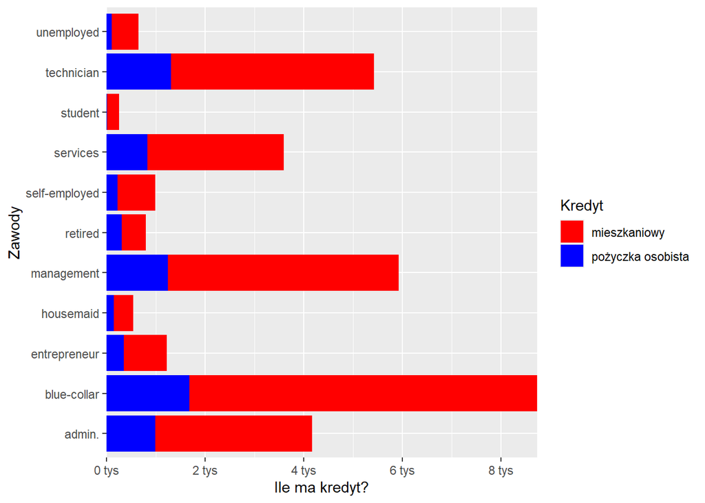

```r
df1 <- df %>%
  filter(job != "unknown") %>%
  group_by(job) %>%
  mutate(loan=ifelse(loan=='yes',1,0), housing=ifelse(housing=='yes',1,0)) %>%
  summarise(count_h=sum(housing),count_l=sum(loan)) %>%
  pivot_longer(cols = c(count_h, count_l), names_to = "type", values_to = "count") %>%
  ggplot(aes(x=count, y=job, fill=type)) +
  geom_col(position="stack") +
  scale_fill_manual(values = c("count_l"="blue", "count_h"="red"),
                    labels=c("count_l"="pożyczka osobista", "count_h"="mieszkaniowy")) +
  scale_x_continuous(expand=c(0,0), labels = label_number(scale = 0.001, suffix=" tys"))+
  labs(
    x="Ile ma kredyt?",
    y="Zawody",
    fill="Kredyt")
df1
```

**Komentarz:Widzimy, że najwięcej kredytów mają ‘blue-collar’ workers, wyróżniają się oni zarówno w ilości kredytów mieszkaniowych, jak i pożyczek osobistych.**

## Zadanie 2

Wybierając klientów, którzy mają nieznany sposób kontaktu (`contact`). Jak rozkłada się ich wiek w podziale na status związku?

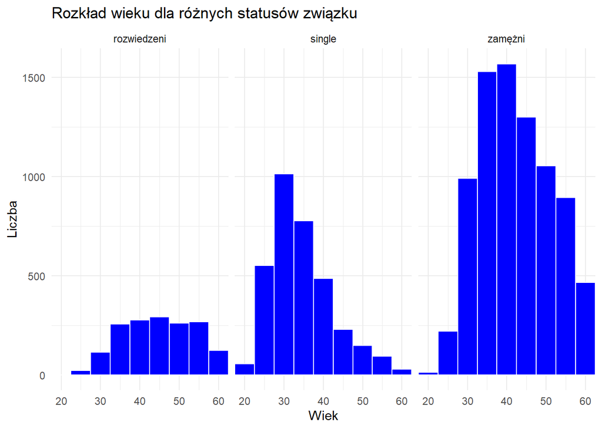

```r
df2 <- df %>%
  mutate(marital=case_when(
                  marital=="married"~"zamężni",
                  marital=="single"~"single",
                  marital=="divorced"~"rozwiedzeni")) %>%
  filter(contact == "unknown") %>%
  select(age, marital)

p_2 <- ggplot(df2, aes(x = age)) +
    geom_histogram(binwidth = 5, fill = "blue", color = "white") +
    facet_wrap(~ marital) +
    theme_minimal() +
    labs(title = "Rozkład wieku dla różnych statusów związku",
       x = "Wiek",
       y = "Liczba") + scale_x_continuous(expand = c(0, 0))
p_2
```

**Komentarz:Widzimy, że u rozwiedzonych podobna liczebność w różnych kategoriach wiekowych. U singli więcej w okolicach 30, a u zamężnych od 35-45 lat.**

## Zadanie 3

Jaka jest różnica pomiędzy średnim rocznym saldem w euro w zależności od wykształcenia i tego czy kredyt jest niespłacany?

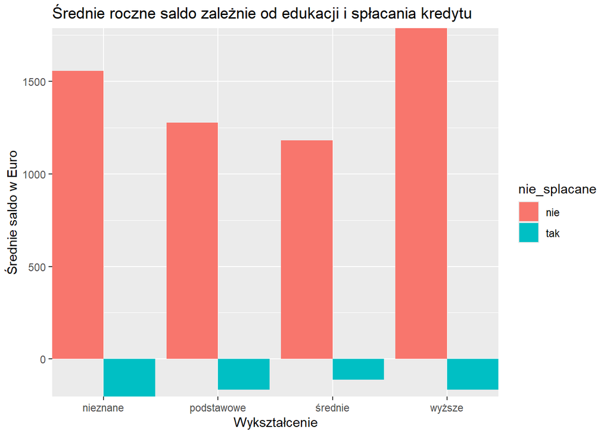

```r
df3 <- df %>%
  select(balance, education, default) %>%
  mutate(education=case_when(
    education=="primary"~"podstawowe",
    education=="secondary"~"średnie",
    education=="tertiary"~"wyższe",
    education=="unknown"~"nieznane")) %>%
  mutate(default=case_when(
    default=="yes"~"tak",
    default=="no"~"nie")) %>%
  rename(nie_splacane = default) %>%
  group_by(education, nie_splacane) %>%
  summarise(mean = mean(balance))

p_3 <- ggplot(df3, aes(x = education, y = mean, fill = nie_splacane)) +
  geom_bar(stat = "identity", position = "dodge") + scale_x_discrete(expand = c(0, 0)) +
  scale_y_continuous(expand = c(0, 0)) +
  labs(x = "Wykształcenie", y = "Średnie saldo w Euro",
       title = "Średnie roczne saldo zależnie od edukacji i spłacania kredytu")
p_3
```

## Zadanie 4

Czy dzień i miesiąc kontaktu z klientem ma wpływ na średni czas trwania rozmowy w stosunku do średniego czasu trwania rozmowy?

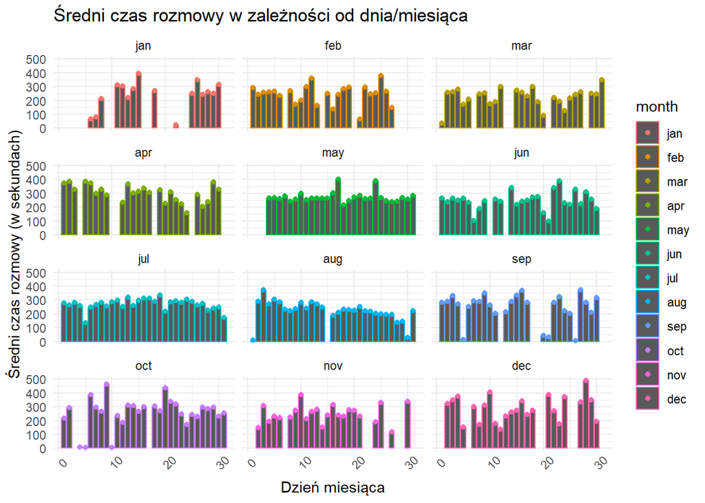

```r
df4 <- df %>%
  mutate(
    month = factor(month, levels = c("jan", "feb", "mar", "apr", "may", "jun",
                                     "jul", "aug", "sep", "oct", "nov", "dec"))) %>%
  group_by(month, day) %>%
  summarise(
    avg_duration = mean(duration, na.rm = TRUE)) %>%
  filter(avg_duration < 500)

p_4 <- ggplot(df4, aes(x = day, y = avg_duration, group = month, color = month)) +
  geom_col() + geom_point() + facet_wrap(~ month, ncol = 3) +
  labs(title = "Średni czas rozmowy w zależności od dnia/miesiąca",
       x = "Dzień miesiąca",
       y = "Średni czas rozmowy (w sekundach)") +
  theme_minimal() +
  theme(axis.text.x = element_text(angle = 45))
p_4
```

## Zadanie 5

Czy jest zależnośc pomiędzy wiekiem klientów a ich średnim rocznym saldzie w euro w podziale na stopień wykształcenia?

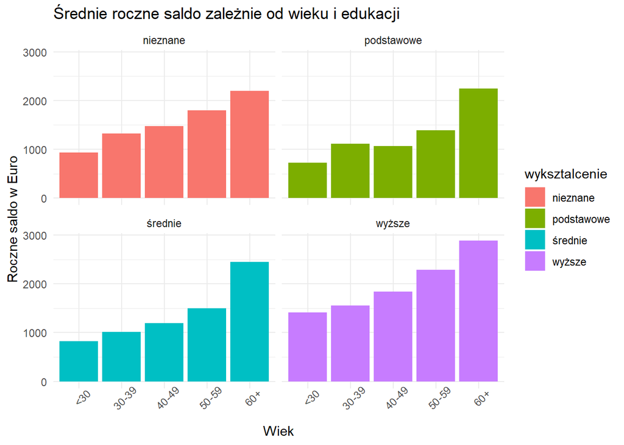

```r
df5 <- df %>%
  select(age, balance, education) %>%
  mutate(age_group = case_when(
    age < 30 ~ "<30",
    age >= 30 & age < 40 ~ "30-39",
    age >= 40 & age < 50 ~ "40-49",
    age >= 50 & age < 60 ~ "50-59",
    age >= 60 ~ "60+")) %>%
  mutate(education=case_when(
    education=="primary"~"podstawowe",
    education=="secondary"~"średnie",
    education=="tertiary"~"wyższe",
    education=="unknown"~"nieznane")) %>%
  rename(wyksztalcenie = education) %>%
    group_by(age_group, wyksztalcenie) %>%
    summarise(mean = mean(balance))

p_5 <-ggplot(df5, aes(x = age_group, y = mean, fill = wyksztalcenie)) +
  geom_bar(stat = "identity", position = "dodge") +
  facet_wrap(~ wyksztalcenie) +
  labs(x = "Wiek", y = "Roczne saldo w Euro",
       title = "Średnie roczne saldo zależnie od wieku i edukacji") +
  theme_minimal() +
  theme(axis.text.x = element_text(angle = 45))
p_5
```

**Komentarz:Widzimy, że z reguły im starszy jest człowiek, tym większe saldo. W dodatku im wyższe wykształcenie tym również wyższe saldo(nie uwzględniając nieznanego wykształcenia).**

## Zadanie 6

Rozważmy osoby, które są bezrobotne albo ich zawód jest nieznany. Czy procent osób, które są bezrobotne i nie spłacają kredytu jest większy od procenta osób o nieznanym zawodzie i nie spłacanym kredycie? Jaki typ kredytu jest (przez te osoby) najczęściej niespłacany?

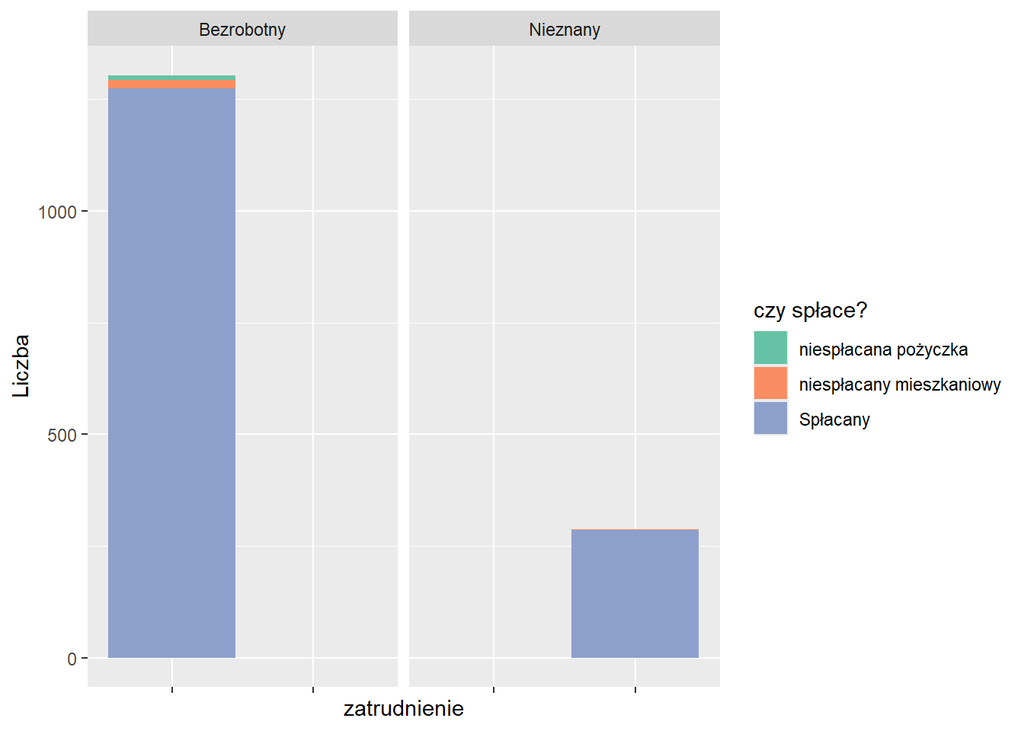

```r
df6 <- df %>%
  filter(job=="unknown" | job=="unemployed") %>%
  mutate(job=ifelse(job=="unknown", "Nieznany","Bezrobotny"),default=case_when(
    default=="no"~"Spłacany",
    default=="yes" & housing=="yes"~"niespłacany mieszkaniowy",
    default=="yes" & housing=="no"~"niespłacana pożyczka"
  )) %>%
  group_by(job, default) %>%
  summarise(count=n()) %>%
  ggplot(aes(x=job, y=count,fill=default)) + geom_col()+
  scale_fill_brewer(palette="Set2") + facet_wrap(~job) + labs(
    x="zatrudnienie", y="Liczba",fill="czy spłace?") +
  theme(axis.text.x = element_blank())
df6
```

**Komentarz:Procent osób bezrobotnych i nie spłacających kredytu jest większy od tych o nieznanym zawodzie. Najczęściej niespłacanym typem kredytu jest kredyt mieszkaniowy.**